# R / RStudio and the tidyverse

## What?

## R and RStudio (1/2)

- R is a programming language
- RStudio is the most widespread **IDE** associated to R
- With Python, R is one of the two top data science languages
- Several million R users worldwide and the number increases rapidly
- Examples of use cases:  
  https://github.com/ThinkR-open/companies-using-r  
  https://rstudio.com/about/customer-stories/

Roughly speaking (very personal opinion):

- R is usually better for **statistics**;
- Python is preferred by computer scientists and people working on very **Deep Learning**;
- both are amazing for **data science**, graphs and simple machine learning.

## R and RStudio (2/2)

Beyond statistical analyses and data science, you can do lots of things with R: reports, **websites**, books, **applications**, and slides (like these ones).  
+ doc & ppt (see https://ardata-fr.github.io/officeverse/), but the latter are usually ugly.

R & RStudio can easily be combined to other languages (Python, C/C++, SQL, JavaScript, etc.).

Moreover, the **R community** is very inclusive and kind.

In short, R is pretty cool. 😎

## The learning curve

“Failure the greatest teacher is.” **Yoda** in *The Last Jedi*.

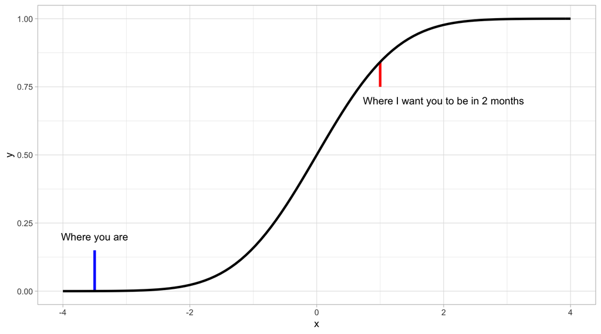

## The end of the learning curve

What does “*where I want you to be*” mean?

Here are 3 examples of some of my students’ **dynamic dashboards**:

https://tania-queuche.shinyapps.io/OBUS/  
https://zeynepbilgihan.shinyapps.io/ibm_hr_data/  
https://carolinechan.shinyapps.io/Apple_Store/

My role/hope is to make you code similar objects.

YOU CAN DO IT!

But you need to start working hard early.

## The philosophy of the course

Knowledge is **not free**: you have to **pay attention**.

- Learning comes from YOU! More than 80% of what you will get from the course will come from your efforts. **Passive listening** \(\neq\) learning.
- Remote teaching is a major barrier! Because attention spans are short, especially in front of pedagogical videos!
- Remote teaching is not a major hurdle! Because anyway, progress will only be made by **practice** (on your computer, outside the video sessions).
- I will always be there to help. Google & stackoverflow are your best friends. I’m next on the list.
- To optimize my feedback, be as precise as possible. (best solution: send me files & code, not screenshots!)

## Errors, errors, errors

[figure not shown]

source: https://github.com/allisonhorst/stats-illustrations

## => Debugging!

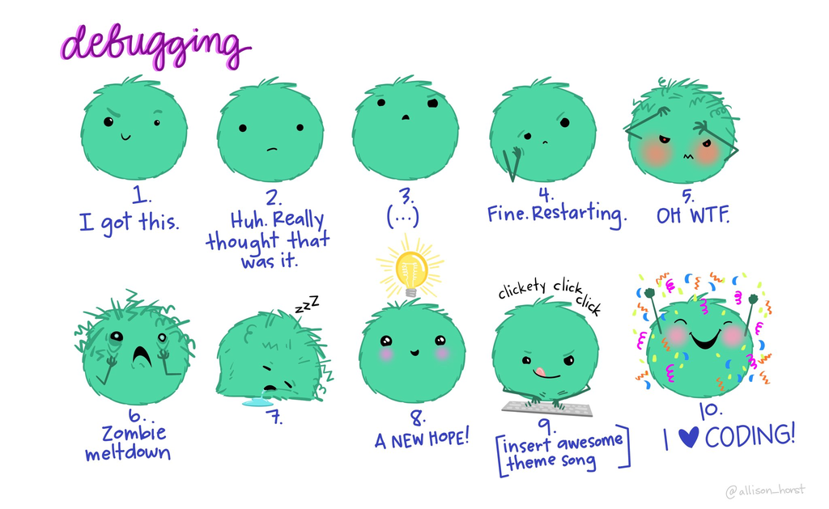

## The data science workflow

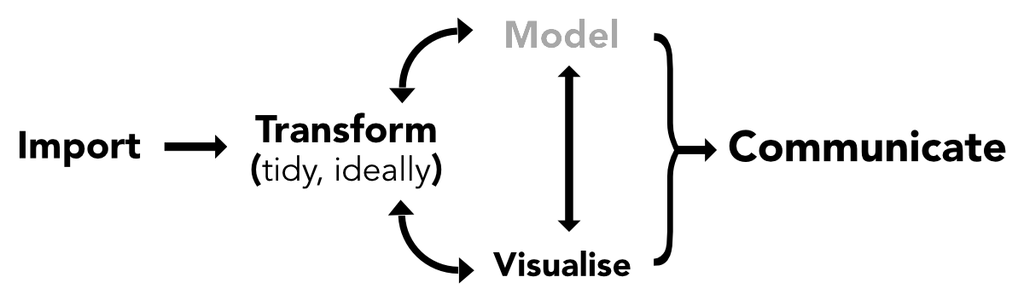

In this course, we will mostly overlook the **Model** part.

My only **goal**: that Excel becomes marginal in your workflow! 😉

## How shall we proceed?

## Course structure (1/2)

1. In-class sessions: mix between slides & tutorials
2. Exercises: **practice** is the most important
3. A **personal project**, in two steps:
- A short presentation of the project + dataset search & formatting ( ~10h work), due **2022-02-06**;
- The full report, code & deployment ( ~20-50h work), due **2022-03-20**;
- Please do not ask for adjournments (the deadlines are comfortable).

Questions & Interactions!

They are **crucial**: don’t be shy, there is no such thing as a bad question.  
There are only bad teachers :)  
Seriously, don’t be shy. 😊  
Often, seemingly ridicule questions are not ridicule at all.  
R is new to you, it can be **overwhelming** (and I know it).

## Course structure (2/2)

1. Introduction to R/RStudio & the **tidyverse**
2. Baseline R & **data structures** + import/export
3. **Plots** + options
4. Shiny 1 - **User interface** & Server
5. Shiny 2 - **UI layout** (organization: tabs, rows, columns, boxes, menus, etc.)
6. Shiny 3 - **Deployment** + further options (CSS, themes & advanced tricks)
7. Geocomputing / APIs / Text Mining
8. Advanced modelling / + options \(\rightarrow\) possibly to be defined together

\(\rightarrow\) Don’t hesitate to submit ideas or wishes!

## What RStudio looks like

[figure not shown]

## The greatness of notebooks

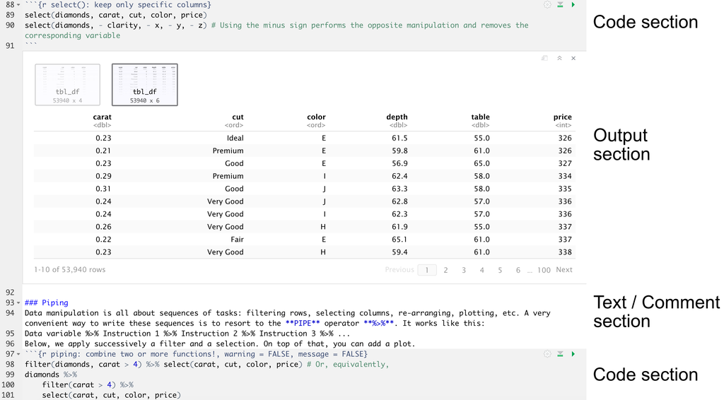

## About packages

One of the great strengths of R is a (very) large collection of **packages**.

Packages are libraries that expand the capabilities of R.

The most important one is in fact a **collection** of packages called the

tidyverse.

It includes:

- **ggplot**: the best plotting engine in the world (seriously)
- **dplyr**: for data manipulation
- **tidyr**: helps you work with tidy data (more on that soon)
- **readr** and **readxl**: import rectangular data files (excel, etc.)
- and more!

## Install packages

There are two steps: first you need to download the package (only once, like pip in Python). The packages are downloaded from servers all around the world. So we start by choosing one.

```r
# chooseCRANmirror() to set downloading location,
chooseCRANmirror(ind = 1)    #  see getCRANmirrors() for geographical details
```

```r
install.packages("tidyverse") # Install (download) package: only once
```

**NOTE** (reminder): it’s easy to install packages directly in RStudio (“Tools” tab). + .libPaths()

Then, if you want to work with it, you need to load/activate it (for every session).

```r
library(tidyverse)            # Loading, like "import..." in Python
```

## “Unofficial” packages

Sometimes, packages are not verified by the **CRAN** (Comprehensive R Archive Network).  
They are simply hosted on Github.  
To install them, use use the **devtools** package:

```r
devtools::install_github("xvrdm/ggrough")
```

But you have to install devtools first!

## Comments and output

- One hashtag # precedes a comment in R code.
- Two hashtags ## precede **output** from a code sequence in the slides or notebooks.

```r
1+1 # Test!
```

```
## [1] 2
```

In these slides, code will appear in grey areas (rectangles).

## The assignment operator <-

In R, we don’t use “=” to create variables, but an arrow sign “<-”.  
Though “=” works, too.

```r
a <- 6 # This creates a variable but does not show it!
a      # If you want to see it, ask for it!
```

```
## [1] 6
```

```r
b <- 11:42  # This creates a variable but does not show it!
b          # If you want to see it, ask for it!
```

```
##  [1] 11 12 13 14 15 16 17 18 19 20 21 22 23 24 25 26 27 28 29 30 31 32 33 34 35
## [26] 36 37 38 39 40 41 42
```

The brackets (ex: [26]) indicate the position of the first element in the row.

## Tidy data via the package *tidyr*

## Many ways to organize data in rectangles, but:

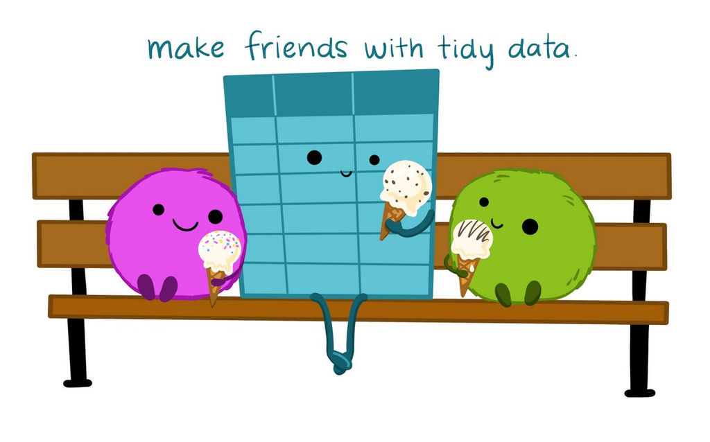

source: Allison Horst & Julia Stewart Lowndes https://www.openscapes.org/blog/2020/10/12/tidy-data/

## Instances vs variables

The **diamonds** database is included in the tidyverse. The **head**() function shows the first lines of a dataset. The **tail**() function shows the *last* lines.

```r
head(diamonds, 4) # The number gives the amount of rows shown
```

| carat | cut | color | clarity | depth | table | price | x | y | z |
| --- | --- | --- | --- | --- | --- | --- | --- | --- | --- |
| 0.23 | Ideal | E | SI2 | 61.5 | 55 | 326 | 3.95 | 3.98 | 2.43 |
| 0.21 | Premium | E | SI1 | 59.8 | 61 | 326 | 3.89 | 3.84 | 2.31 |
| 0.23 | Good | E | VS1 | 56.9 | 65 | 327 | 4.05 | 4.07 | 2.31 |
| 0.29 | Premium | I | VS2 | 62.4 | 58 | 334 | 4.20 | 4.23 | 2.63 |

One **instance** = one observation = one **row**.  
One **variable** = one **unique** characteristic = one **column**.

## Variable types

- **number** (numerical): integer (int) or double (dbl)
- **character**: text (chr)
- **factor**: categorical, ordered (ord) or not (fct)
- **boolean**: TRUE or FALSE / **T** or **F** (bool)
- **date**: day precision (date) or second precision (time): usually starts 1970-01-01

**NOTE**: we are only concerned with rectangular / structured datasets.

## Tidyness structures data & thought

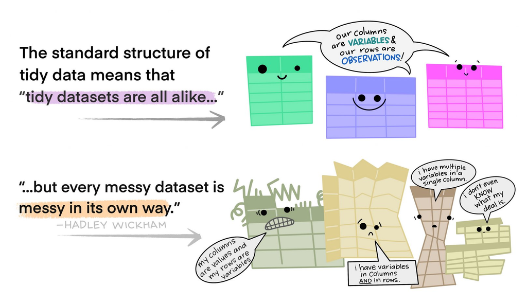

source: Allison Horst & Julia Stewart Lowndes

## Tidy data benefits from hundreds of tools

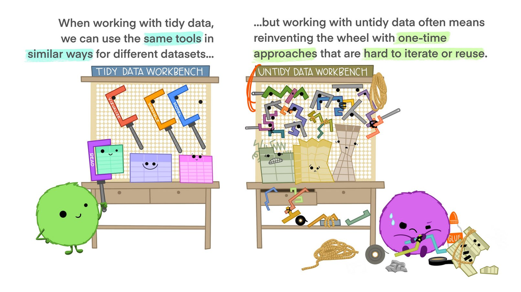

source: Allison Horst & Julia Stewart Lowndes

## Tidy data: example via gapminder

```r
install.packages("gapminder") # Install (download) package: only once
```

Tidy data satisfies the (row = instance) & (column = variable) structure.

```r
library(gapminder)            # Activate: each time you launch RStudio
head(gapminder, 3)            # Have a look!
```

| country | continent | year | lifeExp | pop | gdpPercap |
| --- | --- | --- | --- | --- | --- |
| Afghanistan | Asia | 1952 | 28.801 | 8425333 | 779.4453 |
| Afghanistan | Asia | 1957 | 30.332 | 9240934 | 820.8530 |
| Afghanistan | Asia | 1962 | 31.997 | 10267083 | 853.1007 |

## Tidy data: counter-example

The table below shows the evolution of population of countries.

```r
pivot_wider(gapminder[c(1:4,13:16,25:28), c(1,3,5)],  # Don't look at this code!
            names_from = "country", values_from = "pop")
```

| year | Afghanistan | Albania | Algeria |
| --- | --- | --- | --- |
| 1952 | 8425333 | 1282697 | 9279525 |
| 1957 | 9240934 | 1476505 | 10270856 |
| 1962 | 10267083 | 1728137 | 11000948 |
| 1967 | 11537966 | 1984060 | 12760499 |

\(\rightarrow\) Not tidy! The columns are not **VARIABLES**!  
(This is typically the excel format.)

## Tidy tools (illustration)

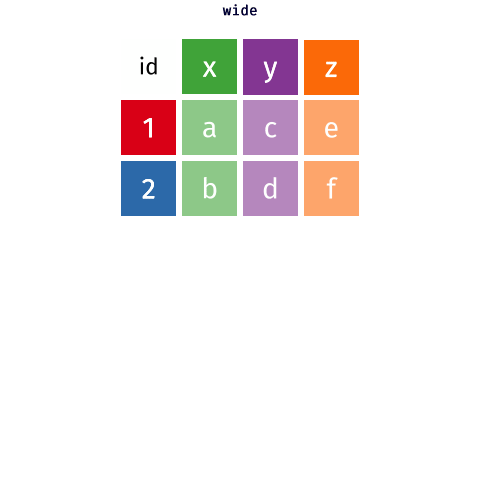

## Tidy tools

The tidyverse has two functions that switch from matrix/excel format to tidy data and back:

- **pivot_longer**(): from matrix/excel to tidy data (wide_to_long/melt in pandas)
- **pivot_wider**(): from tidy data to matrix/excel (pivot in pandas)

Below, one example of data (called “not_tidy_pop”“) in ‘excel’ format.

| Year | France | Germany | UK |
| --- | --- | --- | --- |
| 1970 | 52 | 61 | 56 |
| 1990 | 59 | 80 | 57 |
| 2010 | 65 | 82 | 63 |

**BE VERY CAREFUL**: type case matters in R!  
Continent \(\neq\) continent.  
When referring to a variable (column names), a mistake will lead to an error.

## Tidy tool: **pivot_longer**()! From wide to long.

[figure not shown]

## Tidy tool: **pivot_longer**()! From wide to long.

Gather joins/concatenates columns which belong to the same variable.

```r
tidy_pop <- pivot_longer(not_tidy_pop, cols = -Year, names_to = "Country", values_to = "Population")
```

```r
tidy_pop[1:7,]  # First 7 lines (only) shown
```

| Year | Country | Population |
| --- | --- | --- |
| 1970 | France | 52 |
| 1970 | Germany | 61 |
| 1970 | UK | 56 |
| 1990 | France | 59 |
| 1990 | Germany | 80 |
| 1990 | UK | 57 |
| 2010 | France | 65 |

The syntax is the following:

pivot_longer(**data**,  
\(\quad\) **cols** = columns to tidy,  
\(\quad\) **names_to** = name_of_the_new_variable,  
\(\quad\) **values_to** = name_of_the_column_with_values  
)

**names_to** = Country because the columns are all countries.

**values_to** = Population because the data pertains to population values.

We use -**Year** because the Year variable is excluded from the pivoting

## Visually…

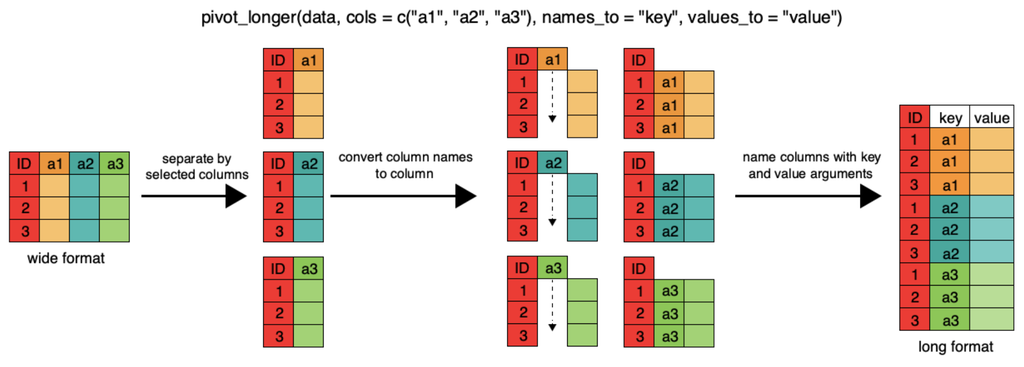

**Source**: software carpentry

## Tidy tools: **pivot_wider**()! From long to wide.

The reverse operation (no need for the “**cols**” argument this time).

```r
pivot_wider(tidy_pop, names_from = "Country", values_from = "Population")
```

| Year | France | Germany | UK |
| --- | --- | --- | --- |
| 1970 | 52 | 61 | 56 |
| 1990 | 59 | 80 | 57 |
| 2010 | 65 | 82 | 63 |

pivot_wider(**data**,  
\(\quad\) **names_from** = variable_to_be_put_in_columns,  
\(\quad\) **values_from** = where_to_get_values  
)

## Data manipulation via the package *dplyr*

## filter() rows - Part I

Often, analyses are performed on subsets of data (query in Python).

```r
filter(gapminder, lifeExp > 81.5) # Countries where people live long lives on average
```

| country | continent | year | lifeExp | pop | gdpPercap |
| --- | --- | --- | --- | --- | --- |
| Hong Kong, China | Asia | 2007 | 82.208 | 6980412 | 39724.98 |
| Iceland | Europe | 2007 | 81.757 | 301931 | 36180.79 |
| Japan | Asia | 2002 | 82.000 | 127065841 | 28604.59 |
| Japan | Asia | 2007 | 82.603 | 127467972 | 31656.07 |
| Switzerland | Europe | 2007 | 81.701 | 7554661 | 37506.42 |

## filter() rows - Part II

Filters can be combined (with commas preferably, the & operator works, too).

```r
filter(gapminder, country == "Japan", year > 2000)
```

| country | continent | year | lifeExp | pop | gdpPercap |
| --- | --- | --- | --- | --- | --- |
| Japan | Asia | 2002 | 82.000 | 127065841 | 28604.59 |
| Japan | Asia | 2007 | 82.603 | 127467972 | 31656.07 |

Only two observations for Japan post-2000.  
**NOTE**: as in **all** languages, there are **TWO EQUAL SIGNS** (==) for the comparison.  
One “=” is like the arrow (<-) and is used to **assign** values.

## select() columns

Sometimes, you might want to keep just a few variables to ease **readability**.

```r
select(gapminder[1:5,], country, year, pop)
```

| country | year | pop |
| --- | --- | --- |
| Afghanistan | 1952 | 8425333 |
| Afghanistan | 1957 | 9240934 |
| Afghanistan | 1962 | 10267083 |
| Afghanistan | 1967 | 11537966 |
| Afghanistan | 1972 | 13079460 |

Use **select**(data, -variable) to **remove** variable: the minus sign!

## Sort via arrange()

This is when you want to **order** your data (sort_values in pandas). Here, from smallest pop to largest.

```r
head(arrange(gapminder, pop)) # Alternative: arrange(gapminder, desc(lifeExp)); desc() is for descending
```

| country | continent | year | lifeExp | pop | gdpPercap |
| --- | --- | --- | --- | --- | --- |
| Sao Tome and Principe | Africa | 1952 | 46.471 | 60011 | 879.5836 |
| Sao Tome and Principe | Africa | 1957 | 48.945 | 61325 | 860.7369 |
| Djibouti | Africa | 1952 | 34.812 | 63149 | 2669.5295 |
| Sao Tome and Principe | Africa | 1962 | 51.893 | 65345 | 1071.5511 |
| Sao Tome and Principe | Africa | 1967 | 54.425 | 70787 | 1384.8406 |
| Djibouti | Africa | 1957 | 37.328 | 71851 | 2864.9691 |

## Create new columns via mutate()

With population and gdpPercap you can infer total GDP!

```r
head(mutate(gapminder, gdp = pop * gdpPercap))
```

| country | continent | year | lifeExp | pop | gdpPercap | gdp |
| --- | --- | --- | --- | --- | --- | --- |
| Afghanistan | Asia | 1952 | 28.801 | 8425333 | 779.4453 | 6567086330 |
| Afghanistan | Asia | 1957 | 30.332 | 9240934 | 820.8530 | 7585448670 |
| Afghanistan | Asia | 1962 | 31.997 | 10267083 | 853.1007 | 8758855797 |
| Afghanistan | Asia | 1967 | 34.020 | 11537966 | 836.1971 | 9648014150 |
| Afghanistan | Asia | 1972 | 36.088 | 13079460 | 739.9811 | 9678553274 |
| Afghanistan | Asia | 1977 | 38.438 | 14880372 | 786.1134 | 11697659231 |

## Piping: %>%

## Definition: sequences of operations

**Very often**, one simple analysis will require several steps. They can be combined via the **%>%** operator.

A fake sequence:

**me** %>%  
\(\quad\) **wake_up**(time = “06:20”) %>%  
\(\quad\) **shower**(temp = 40) %>%  
\(\quad\) **go_to**(place = “baker”, with = “scooter”) %>%  
\(\quad\) **buy**(item = “bread”) %>%  
\(\quad\) **go_to**(place = “home”, with = “scooter”) %>%  
\(\quad\) **breakfast**(drink = “hot_chocolate”, eat = “toast”, eat = “kiwi”) %>%  
\(\quad\) **toothbrush**(duration = 2)

## Example (short)

```r
select(filter(diamonds, carat > 4), carat, price, clarity) # BEURK!
```

```r
diamonds %>%
    filter(carat > 4) %>%
    select(carat, price, clarity)  # So simple!
```

| carat | price | clarity |
| --- | --- | --- |
| 4.01 | 15223 | I1 |
| 4.01 | 15223 | I1 |
| 4.13 | 17329 | I1 |
| 5.01 | 18018 | I1 |
| 4.50 | 18531 | I1 |

## Example (long)

```r
diamonds %>%
    filter(carat > 2, cut == "Ideal") %>%      # First we filter
    mutate(car_price_ratio = carat/price) %>%  # Then, we create a new column
    arrange(desc(car_price_ratio)) %>%         # We order the data
    select(-x, -y, -z) %>%                     # We take out some superfluous columns
    head(4)                                    # Finally, we ask for the top 4 instances
```

| carat | cut | color | clarity | depth | table | price | car_price_ratio |
| --- | --- | --- | --- | --- | --- | --- | --- |
| 3.50 | Ideal | H | I1 | 62.8 | 57 | 12587 | 0.0002781 |
| 3.22 | Ideal | I | I1 | 62.6 | 55 | 12545 | 0.0002567 |
| 2.16 | Ideal | H | I1 | 62.2 | 56 | 8709 | 0.0002480 |
| 2.25 | Ideal | E | I1 | 61.4 | 54 | 9072 | 0.0002480 |

## Pivot tables

## Definition

“*A pivot table is a table of statistics that summarizes the data of a more extensive table.*”

— Wikipedia

There are two dimensions in a pivot table:  
- which **variable**(s) we want to analyze (gender, continent/country, size, etc.);  
- which **statistic** we want to compute (mean, min, max, number of instances, variance etc.).

In R, these two steps are separated via two functions: **group_by**() and **summarise**()

## Example I

```r
diamonds %>%
    group_by(clarity, cut) %>%              # Define the variables
    summarise(avg_price = mean(price),      # Define the statistics
              avg_carat = mean(carat)) %>%  # Second stats
    head(4)
```

| clarity | cut | avg_price | avg_carat |
| --- | --- | --- | --- |
| I1 | Fair | 3703.533 | 1.361000 |
| I1 | Good | 3596.635 | 1.203021 |
| I1 | Very Good | 4078.226 | 1.281905 |
| I1 | Premium | 3947.332 | 1.287024 |

## Example II

You can even pipe inside a function!

```r
gapminder %>%
    group_by(continent, year) %>%
    summarise(avg_lifeExp = mean(lifeExp) %>% round(2)) %>%
    head(4)
```

| continent | year | avg_lifeExp |
| --- | --- | --- |
| Africa | 1952 | 39.14 |
| Africa | 1957 | 41.27 |
| Africa | 1962 | 43.32 |
| Africa | 1967 | 45.33 |

The **round**() function rounds numbers up to some decimals.

## Bonus: tutors!

- visualize tidyverse code: https://tidydatatutor.com
- equivalent for **pandas**: https://pandastutor.com

## Takeaway

## Summary

R is an incredibly powerful tool for data science. The preferred environment is the **tidyverse**. As its name indicates, the core concept is **TIDY DATA**!

In short, it’s just a question of functions:  
- **pivot_longer()** and **pivot_wider()** to work with tidy data;  
- **filter()**, **select()**, **arrange()** and **mutate()** for wrangling/manipulation;  
- **group_by()** and **summarize()** for pivot tables;  
- **head()** and **tail()** to see the first and last lines of a dataset.

That’s it!

## Resources / Links

- an online series of exercises with solutions!:  
  https://gcoqueret.shinyapps.io/Exercises/
- the Bible of Data Science with R:  
  https://r4ds.had.co.nz
- Two great books on data science:  
  https://ubc-dsci.github.io/introduction-to-datascience/  
  https://rafalab.github.io/dsbook/
- Shiny use cases:  
  https://shiny.rstudio.com/gallery/
- One other app (marketing):  
  https://mdancho84.shinyapps.io/shiny-app/

## What are your questions?

A ‘bad’ question is better than no question (there are no bad questions).

- Programming AND learning to code is **HARD**:
- Ask questions so I can make it (slightly) easier.
- I can’t guess your questions, don’t be shy!
- Nothing will replace **practice** & making **mistakes**.

**Tip**: for your project, choose a dataset with a mixture of numerical and categorical data. It is the best combination to create a nice looking dashboard!